# Community detection

Pablo Barbera

October 31, 2017

#### Importing network data into R

In this guided coding session we will be using a small dataset to illustrate how to identify latent communities in networks. The dataset corresponds to the Twitter ego network of USC POIR – each node is another Twitter account that the USC POIR account follows, and the edges indicate whether each of those accounts in turn follow each other. (See at the end of this script for the code on how I put together this network.) Edges are thus directed.

The first step is to read the list of edges and nodes in this network:

```r
edges <- read.csv("../data/poir-edges.csv", stringsAsFactors=FALSE)
head(edges)
```

```
##      Source     Target
## 1 112448318  116630713
## 2 112448318  119679411
## 3 112448318  119682506
## 4 112448318  135469780
## 5 112448318 1852171094
## 6 112448318  186894716
```

```r
nodes <- read.csv("../data/poir-nodes.csv", stringsAsFactors=FALSE)
head(nodes)
```

```
##           Id          Label                name
## 1  112448318         BJPolS British Jnl Pol Sci
## 2 1137637033    AJPS_Editor                AJPS
## 3  114865774    USCGouldLaw       USC Gould Law
## 4  116630713 monkeycageblog         Monkey Cage
## 5 1180479770          jaj7d        Jeff Jenkins
## 6  119679411    EPSRjournal Euro Pol Sci Review
##                                                                                                                                  description
## 1                                                                      British Journal of Political Science from Cambridge University Press.
## 2                                                                                                      American Journal of Political Science
## 3                                     A top-20 law school, USC Gould offers students a world-class education and unparalleled opportunities.
## 4 H.L. Mencken said: "Democracy is the art of running the circus from the monkey cage." We do political science and politics. Tweets by bot.
## 5                                           Provost Professor of Public Policy, Political Science, and Law. @USC\nDirector, @BedrosianCenter
## 6                                                European Political Science Review, the new journal from ECPR and Cambridge University Press
##   followers_count statuses_count friends_count
```

[output cut: 27 more lines]

For example, we learn that user with ID 112448318 follows user with ID 116630713

We will now convert these two datasets into a network object in R using `igraph`.

```r
library(igraph)
g <- graph_from_data_frame(d=edges, vertices=nodes, directed=TRUE)
g
```

```
## IGRAPH DN-- 135 2654 --
## + attr: name (v/c), Label (v/c), description (v/c),
## | followers_count (v/n), statuses_count (v/n), friends_count
## | (v/n), created_at (v/c), location (v/c), lang (v/c), time_zone
## | (v/c), status.id_str (v/n), status.created_at (v/c), status.text
## | (v/c)
## + edges (vertex names):
## [1] British Jnl Pol Sci->Monkey Cage
## [2] British Jnl Pol Sci->Euro Pol Sci Review
## [3] British Jnl Pol Sci->International Theory
## [4] British Jnl Pol Sci->EPSA
## + ... omitted several edges
```

#### Network communities

Networks often have different clusters or communities of nodes that are more densely connected to each other than to the rest of the network. Let’s cover some of the different existing methods to identify these communities.

The most straightforward way to partition a network is into **connected components**. Each component is a group of nodes that are connected to each other, but *not* to the rest of the nodes. For example, this network has only one component (every node is at least connected to one other node in the network).

```r
components(g)
```

```
## $membership
##  British Jnl Pol Sci                 AJPS        USC Gould Law
##                    1                    1                    1
##          Monkey Cage         Jeff Jenkins  Euro Pol Sci Review
##                    1                    1                    1
## International Theory Innovation @ Harvard         USC Dornsife
##                    1                    1                    1
##        USC Sociology                 SPSA                 ACLU
##                    1                    1                    1
##                 EPSA  USC History Dept. ✌️            Ray Kwong
##                    1                    1                    1
##          Rod Albuyeh   Sen. Barbara Boxer   USC Religious Life
##                    1                    1                    1
##         Jay Maharjan            USA TODAY         USC Research
##                    1                    1                    1
##         USC Marshall                 NCSL      Jason Giannaros
##                    1                    1                    1
##    Los Angeles Times        Eric Garcetti               AnnLab
##                    1                    1                    1
##          Marist Poll                 MPSA         Daily Trojan
##                    1                    1                    1
##   USC Annenberg CCLP   Political Analysis Jordan Carr Peterson
##                    1                    1                    1
##          USC Rossier             USC EASC          Jerry Brown
##                    1                    1                    1
##                  USC USC PoliticalScience   Norman Lear Center
##                    1                    1                    1
##            Tim Scott           Kyuri Park        USC Libraries
##                    1                    1                    1
##      FiveThirtyEight             CSII USC          Adam Badawy
##                    1                    1                    1
##      Christian Grose        Taylor Dalton      Washington Post
##                    1                    1                    1
## USC Shoah Foundation     Youssef Chouhoud       Fanny Cisneros
##                    1                    1                    1
##         CUP Politics         Robert Shrum                  PSA
##                    1                    1                    1
## USC Visions & Voices        USC Annenberg    USC Wrigley Inst.
##                    1                    1                    1
##   USC Viterbi School                  PSQ    American_Politics
```

[output cut: 42 more lines]

```
##                    1                    1                    1
##         Brett Carter    NetDem Lab at USC            Abby Wood
##                    1                    1                    1
##              theWPSA             SPEC Lab    Stefanie Neumeier
##                    1                    1                    1
##        Andy Sinclair         Brian Knafou     USC Price School
##                    1                    1                    1
##    Kelebogile Zvobgo Victoria Chonn Ching         PSRM journal
##                    1                    1                    1
##
## $csize
## [1] 135
##
## $no
## [1] 1
```

Most networks have a single **giant connected component** that includes most nodes. Most studies of networks actually focus on the giant component (e.g. the shortest path between nodes in a network with two or more component is Inf!).

```r
giant <- decompose(g)
giant
```

```
## [[1]]
## IGRAPH DN-- 135 2654 --
## + attr: name (v/c), Label (v/c), description (v/c),
## | followers_count (v/n), statuses_count (v/n), friends_count
## | (v/n), created_at (v/c), location (v/c), lang (v/c), time_zone
## | (v/c), status.id_str (v/n), status.created_at (v/c), status.text
## | (v/c)
## + edges (vertex names):
## [1] British Jnl Pol Sci->Monkey Cage
## [2] British Jnl Pol Sci->Euro Pol Sci Review
## [3] British Jnl Pol Sci->International Theory
## [4] British Jnl Pol Sci->EPSA
## + ... omitted several edges
```

Even within a giant component, there can be different subsets of the network that are more connected to each other than to the rest of the network. The goal of **community detection algorithms** is to identify these subsets.

There are a few different algorithms, each following a different logic.

The **walktrap** algorithm finds communities through a series of short random walks. The idea is that these random walks tend to stay within the same community. The length of these random walks is 4 edges by default, but you may want to experiment with different values (longer random walks will lead to fewer communities). The goal of this algorithm is to identify the partition that maximizes a modularity score.

```r
cluster_walktrap(g)
```

```
## IGRAPH clustering walktrap, groups: 4, mod: 0.3
## + groups:
##   $`1`
##    [1] "Innovation @ Harvard" "USC Dornsife"         "ACLU"
##    [4] "Rod Albuyeh"          "Sen. Barbara Boxer"   "USA TODAY"
##    [7] "NCSL"                 "Jason Giannaros"      "Los Angeles Times"
##   [10] "Marist Poll"          "Jordan Carr Peterson" "Jerry Brown"
##   [13] "USC PoliticalScience" "Tim Scott"            "Kyuri Park"
##   [16] "FiveThirtyEight"      "Adam Badawy"          "Christian Grose"
##   [19] "Taylor Dalton"        "Washington Post"      "Youssef Chouhoud"
##   [22] "Fanny Cisneros"       "Robert Shrum"         "American_Politics"
##   [25] "M Drake Reitan"       "Anne van Wijk"        "Whitney Hua"
##   + ... omitted several groups/vertices
```

```r
cluster_walktrap(g, steps=10)
```

```
## IGRAPH clustering walktrap, groups: 3, mod: 0.34
## + groups:
##   $`1`
##    [1] "Innovation @ Harvard" "ACLU"                 "Rod Albuyeh"
##    [4] "Sen. Barbara Boxer"   "USA TODAY"            "NCSL"
##    [7] "Jason Giannaros"      "Los Angeles Times"    "Marist Poll"
##   [10] "Jordan Carr Peterson" "Tim Scott"            "Kyuri Park"
##   [13] "FiveThirtyEight"      "Adam Badawy"          "Christian Grose"
##   [16] "Taylor Dalton"        "Washington Post"      "Youssef Chouhoud"
##   [19] "Fanny Cisneros"       "Robert Shrum"         "Anne van Wijk"
##   [22] "Whitney Hua"          "Wall Street Journal"  "sara sadhwani"
##   [25] "Nola Haynes"          "Tyler Bonanno-Curley" "USC SIR"
##   + ... omitted several groups/vertices
```

```r
cluster_walktrap(g, steps=20)
```

```
## IGRAPH clustering walktrap, groups: 3, mod: 0.3
## + groups:
##   $`1`
##    [1] "British Jnl Pol Sci"  "AJPS"                 "Monkey Cage"
##    [4] "Jeff Jenkins"         "Euro Pol Sci Review"  "International Theory"
##    [7] "SPSA"                 "EPSA"                 "Rod Albuyeh"
##   [10] "NCSL"                 "Jason Giannaros"      "Marist Poll"
##   [13] "MPSA"                 "Political Analysis"   "Jordan Carr Peterson"
##   [16] "Tim Scott"            "Kyuri Park"           "FiveThirtyEight"
##   [19] "Adam Badawy"          "Christian Grose"      "Youssef Chouhoud"
##   [22] "CUP Politics"         "PSA"                  "PSQ"
##   [25] "American_Politics"    "Journal of Politics"  "Anne van Wijk"
##   + ... omitted several groups/vertices
```

```r
cluster_walktrap(g, steps=30)
```

```
## IGRAPH clustering walktrap, groups: 3, mod: 0.3
## + groups:
##   $`1`
##    [1] "British Jnl Pol Sci"  "AJPS"                 "Monkey Cage"
##    [4] "Jeff Jenkins"         "Euro Pol Sci Review"  "International Theory"
##    [7] "SPSA"                 "EPSA"                 "Rod Albuyeh"
##   [10] "NCSL"                 "Jason Giannaros"      "Marist Poll"
##   [13] "MPSA"                 "Political Analysis"   "Jordan Carr Peterson"
##   [16] "Tim Scott"            "Kyuri Park"           "FiveThirtyEight"
##   [19] "Adam Badawy"          "Christian Grose"      "Youssef Chouhoud"
##   [22] "CUP Politics"         "PSA"                  "PSQ"
##   [25] "American_Politics"    "Journal of Politics"  "Anne van Wijk"
##   + ... omitted several groups/vertices
```

Other methods are:

- The **infomap** method attempts to map the flow of information in a network, and the different clusters in which information may get remain for longer periods. Similar to walktrap, but not necessarily maximizing modularity, but rather the so-called “map equation”.
- The **edge-betweenness** method iteratively removes edges with high betweenness, with the idea that they are likely to connect different parts of the network. Here betweenness (gatekeeping potential) applies to edges, but the intuition is the same.
- The **label propagation** method labels each node with unique labels, and then updates these labels by choosing the label assigned to the majority of their neighbors, and repeat this iteratively until each node has the most common labels among its neighbors.
- The **Louvain algorithm** initially assigns each node to its own community; nodes are then sequentially assigned to the community that increases modularity (if any) so that communities are merged; this merging process continues until modularity cannot increase or only one community remains.

```r
cluster_infomap(g)
```

```
## IGRAPH clustering infomap, groups: 4, mod: 0.35
## + groups:
##   $`1`
##    [1] "USC Gould Law"        "USC Dornsife"         "USC Sociology"
##    [4] "USC History Dept. ✌️"  "USC Religious Life"   "Jay Maharjan"
##    [7] "USC Research"         "USC Marshall"         "Eric Garcetti"
##   [10] "AnnLab"               "Daily Trojan"         "USC Annenberg CCLP"
##   [13] "USC Rossier"          "USC EASC"             "USC"
##   [16] "USC PoliticalScience" "Norman Lear Center"   "USC Libraries"
##   [19] "CSII USC"             "USC Shoah Foundation" "Robert Shrum"
##   [22] "USC Visions & Voices" "USC Annenberg"        "USC Wrigley Inst."
##   [25] "USC Viterbi School"   "M Drake Reitan"       "USC EALC"
##   + ... omitted several groups/vertices
```

```r
cluster_edge_betweenness(g)
```

```
## IGRAPH clustering edge betweenness, groups: 91, mod: 0.033
## + groups:
##   $`1`
##    [1] "British Jnl Pol Sci"  "AJPS"                 "Monkey Cage"
##    [4] "Euro Pol Sci Review"  "ACLU"                 "USA TODAY"
##    [7] "Los Angeles Times"    "MPSA"                 "Kyuri Park"
##   [10] "FiveThirtyEight"      "Adam Badawy"          "Washington Post"
##   [13] "CUP Politics"         "M Drake Reitan"       "Anne van Wijk"
##   [16] "Whitney Hua"          "Wall Street Journal"  "sara sadhwani"
##   [19] "Nola Haynes"          "Adam Feldman"         "Megan Eme"
##   [22] "RISIST"               "APSA"                 "Meredith Shaw"
##   [25] "The Associated Press" "Ronan Fu"             "Dave Kang"
##   + ... omitted several groups/vertices
```

```r
cluster_label_prop(g)
```

```
## IGRAPH clustering label propagation, groups: 1, mod: 0
## + groups:
##   $`1`
##     [1] "British Jnl Pol Sci"  "AJPS"
##     [3] "USC Gould Law"        "Monkey Cage"
##     [5] "Jeff Jenkins"         "Euro Pol Sci Review"
##     [7] "International Theory" "Innovation @ Harvard"
##     [9] "USC Dornsife"         "USC Sociology"
##    [11] "SPSA"                 "ACLU"
##    [13] "EPSA"                 "USC History Dept. ✌️"
##    [15] "Ray Kwong"            "Rod Albuyeh"
##    [17] "Sen. Barbara Boxer"   "USC Religious Life"
##   + ... omitted several groups/vertices
```

```r
cluster_louvain(as.undirected(g))
```

```
## IGRAPH clustering multi level, groups: 4, mod: 0.33
## + groups:
##   $`1`
##    [1] "British Jnl Pol Sci"  "AJPS"                 "Monkey Cage"
##    [4] "Jeff Jenkins"         "Euro Pol Sci Review"  "International Theory"
##    [7] "SPSA"                 "EPSA"                 "MPSA"
##   [10] "Political Analysis"   "Jordan Carr Peterson" "FiveThirtyEight"
##   [13] "CUP Politics"         "PSA"                  "PSQ"
##   [16] "American_Politics"    "Journal of Politics"  "JEPS"
##   [19] "sara sadhwani"        "PGI"                  "APSA"
##   [22] "Sangay Mishra"        "Political Data"       "ISA"
##   [25] "Abby Wood"            "theWPSA"              "Stefanie Neumeier"
##   + ... omitted several groups/vertices
```

The choice of one or other algorithm may depend on substantive or practical reasons, as always. For now, let’s pick the Louvain algorithm.

```r
comm <- cluster_louvain(as.undirected(g))
nodes$cluster <- membership(comm)
```

```r
nodes$Label[nodes$cluster==1]
```

```
##  [1] "BJPolS"          "AJPS_Editor"     "monkeycageblog"
##  [4] "jaj7d"           "EPSRjournal"     "InternatlTheory"
##  [7] "SPSAnews"        "europsa"         "MPSAnet"
## [10] "polanalysis"     "JordanCarrP"     "FiveThirtyEight"
## [13] "CUP_PoliSci"     "PolStudiesAssoc" "PSQ_CSPC"
## [16] "PSA_APG"         "The_JOP"         "JEPS_ed"
## [19] "sarasadhwani"    "PGI_WPSA"        "APSAtweets"
## [22] "SangayMishra"    "Political_Data"  "isanet"
## [25] "yesthatabbywood" "theWPSA"         "SteffiNeumeier"
## [28] "jandrewsinclair" "PSRMJournal"
```

```r
nodes$Label[nodes$cluster==2]
```

```
##  [1] "ACLU"           "raykwong"       "RodAlbuyeh"     "jasongiannaros"
##  [5] "kyuripark1"     "adambbadawy"    "christiangrose" "taylordalton"
##  [9] "_abuelbanat"    "BobShrum"       "mdrakereitan"   "annevwijk"
## [13] "whitney_hua"    "USC_SIR"        "AdamSFeldman"   "N_Albertoni"
## [17] "verbal_gaffe"   "changmishaw"    "p_barbera"      "USC_Econ"
## [21] "brynrosenfeld"  "ronantfu"       "daveckang"      "joeyhuddleston"
## [25] "KyleSRapp"      "markpa84"       "geniia_iakhnis" "UscCis"
## [29] "baggottcarter"  "brett_l_carter" "NetDem_USC"     "SPECLabUSC"
## [33] "Bknafou"        "kelly_zvobgo"   "V_Chonn"
```

```r
nodes$Label[nodes$cluster==3]
```

```
##  [1] "USCGouldLaw"     "USCDornsife"     "USC_Soci"
##  [4] "USCHistory"      "USCRELIGIOUSLIF" "4entrepreneur"
##  [7] "USC_Research"    "USCMarshall"     "ericgarcetti"
## [10] "annenberglab"    "dailytrojan"     "USC_CCLP"
## [13] "USCRossier"      "USCeasc"         "JerryBrownGov"
## [16] "USC"             "USCPOSC"         "LearCenter"
## [19] "USCLibraries"    "CSII_USC"        "USCShoahFdn"
## [22] "VisionsnVoices"  "USCAnnenberg"    "USCWrigleyInst"
## [25] "USCViterbi"      "USC_EALC"        "USC_CFR"
## [28] "USCDermatology"  "AngeMarieH"      "PERE_USC"
## [31] "UnruhInstitute"  "CAgovernment"    "USCKSI"
## [34] "uscsocialwork"   "FulbrightPrgrm"  "USCGSG"
## [37] "USCPolymathy"    "BedrosianCenter" "USCCinema"
## [40] "CSatUSC"         "usccrcc"         "PublicDiplomacy"
## [43] "USCAnnenbergPhD" "KeckMedUSC"      "USCGradSchool"
## [46] "USCPrice"
```

```r
nodes$Label[nodes$cluster==4]
```

```
##  [1] "GovInnovations"  "SenatorBoxer"    "USATODAY"
##  [4] "NCSLorg"         "latimes"         "maristpoll"
##  [7] "SenatorTimScott" "washingtonpost"  "fancis30"
## [10] "WSJ"             "nolahtheveil"    "curleyt13"
## [13] "megan_eme"       "LegalAidLA"      "HarrisPoll"
## [16] "AP_Politics"     "LongBeachMayor"  "SenFeinstein"
## [19] "AP"              "Gallup"          "PennFels"
## [22] "pongkwans"       "CNN"             "QuinnipiacPoll"
## [25] "nytimes"
```

```r
table(grepl("los angeles", nodes$location, ignore.case=TRUE),
      nodes$cluster)
```

```
##
##          1  2  3  4
##   FALSE 25 11 10 20
##   TRUE   4 24 36  5
```

```r
library(quanteda)
for (i in 1:4){
  message("Cluster ", i)
  dfm <- dfm(nodes$description[nodes$cluster==i],
             remove_punct=TRUE, remove=stopwords("english"))
  print(topfeatures(dfm, n=25))
}
```

```
## Cluster 1
```

```
##     political       science      politics       journal   association
##            25            21            11             9             8
## international    university      research           law      american
##             7             6             6             5             4
##     published     cambridge         press     professor      european
##             4             3             3             3             3
##           phd       studies         study        public        policy
##             3             3             3             2             2
##   endorsement     candidate       twitter     relations  experimental
##             2             2             2             2             2
```

```
## Cluster 2
```

```
##     political       science           phd           usc       student
##            13            10             9             8             7
##     relations      southern    california international        social
##             7             7             7             7             6
##     candidate    university          @usc      politics     professor
##             6             6             5             5             5
##          ph.d         media     assistant         https          t.co
##             4             4             4             3             3
##      director      research  organization            us     institute
##             3             3             2             2             2
```

```
## Cluster 3
```

```
##        usc     school    account university   official     public
##         21         10          9          8          8          8
##   southern california         us   research  education     follow
##          7          7          7          7          6          6
##    twitter     center department       news      study   students
##          6          6          5          5          5          4
##     across     social        rts      media       t.co     policy
##          4          4          4          4          4          4
##     offers
##          3
```

```
## Cluster 4
```

```
##       news       t.co      https     public   breaking government
##          9          9          6          4          4          3
##        u.s    senator   official      state       http       poll
##          3          3          3          3          3          3
##    opinion     follow    harvard innovation california     latest
##          3          3          2          2          2          2
##    stories    twitter   national        est        los    angeles
##          2          2          2          2          2          2
##      world
##          2
```

```r
# description
poir <- dfm(corpus(nodes[,c("description", "cluster")], text_field="description"))
for (i in 1:4){
    print(
      head(textstat_keyness(poir, target=docvars(poir)$cluster==i,
                      measure="lr"), n=20)
    )
}
```

```
##                      G2            p n_target n_reference
## political     37.818263 7.765143e-10       25          14
## science       31.279728 2.234002e-08       21          12
## journal       24.331179 8.111543e-07        9           0
## association   21.149616 4.247864e-06        8           0
## politics      10.955381 9.333220e-04       11           9
## published      8.695019 3.190807e-03        4           0
## law            6.732350 9.467980e-03        5           2
## american       6.029723 1.406694e-02        4           1
## cambridge      5.718189 1.679004e-02        3           0
## european       5.718189 1.679004e-02        3           0
## that           5.718189 1.679004e-02        3           0
## international  5.246374 2.199255e-02        7           7
## press          3.558967 5.922460e-02        3           1
## we             3.558967 5.922460e-02        3           1
## "              2.887638 8.926168e-02        2           0
## experimental   2.887638 8.926168e-02        2           0
## western        2.887638 8.926168e-02        2           0
## methods        2.887638 8.926168e-02        2           0
## the            2.427361 1.192335e-01       29          86
## research       1.986965 1.586586e-01        6          10
##                     G2           p n_target n_reference
## phd           7.346920 0.006717776        9           6
## ph.d          7.261400 0.007045235        4           0
## candidate     7.156528 0.007469165        6           2
## ,             6.902388 0.008608070       49          98
## ;             6.748438 0.009382978        8           5
## student       6.166356 0.013020257        7           4
## relations     6.166356 0.013020257        7           4
## at            6.065362 0.013785852       13          16
## (             5.669637 0.017261024        8           6
## )             5.669637 0.017261024        8           6
## |             4.854353 0.027576447       10          12
## social        4.422759 0.035462647        6           4
## in            3.880020 0.048863965       13          20
## professor     3.811790 0.050893033        5           3
## @usc          3.811790 0.050893033        5           3
## international 3.350260 0.067194398        7           7
## assistant     3.218875 0.072793641        4           2
## southern      2.706054 0.099968002        7           8
```

[output cut: 29 more lines]

```
## t.co        8.109129 4.404288e-03        9           8
## :           6.642950 9.954894e-03       13          21
## senator     5.745174 1.653402e-02        3           0
## poll        5.745174 1.653402e-02        3           0
## https       4.355313 3.689367e-02        6           6
## government  3.583236 5.836536e-02        3           1
## u.s         3.583236 5.836536e-02        3           1
## opinion     3.583236 5.836536e-02        3           1
## harvard     2.903270 8.840004e-02        2           0
## stories     2.903270 8.840004e-02        2           0
## national    2.903270 8.840004e-02        2           0
## est         2.903270 8.840004e-02        2           0
## los         2.903270 8.840004e-02        2           0
## angeles     2.903270 8.840004e-02        2           0
## editors     2.903270 8.840004e-02        2           0
```

```r
# location
poir <- dfm(corpus(nodes[,c("location", "cluster")], text_field="location"))
for (i in 1:4){
    print(
      head(textstat_keyness(poir, target=docvars(poir)$cluster==i,
                      measure="lr"), n=20)
    )
}
```

```
##                  G2          p n_target n_reference
## new        6.071688 0.01373657        4           2
## uk         3.631702 0.05668882        2           0
## university 3.631702 0.05668882        2           0
## united     3.631702 0.05668882        2           0
## ny         3.425055 0.06421409        3           2
## york       3.425055 0.06421409        3           2
## states     2.040867 0.15312233        2           1
## cambridge  0.675642 0.41109145        1           0
## atlanta    0.675642 0.41109145        1           0
## ga         0.675642 0.41109145        1           0
## europe     0.675642 0.41109145        1           0
## #mpsa18    0.675642 0.41109145        1           0
## april      0.675642 0.41109145        1           0
## 5-8        0.675642 0.41109145        1           0
## chicago    0.675642 0.41109145        1           0
## london     0.675642 0.41109145        1           0
## texas      0.675642 0.41109145        1           0
## a          0.675642 0.41109145        1           0
## &          0.675642 0.41109145        1           0
## m          0.675642 0.41109145        1           0
##                    G2         p n_target n_reference
## ca          2.2540208 0.1332677       20          33
## seoul       1.8338339 0.1756754        2           0
## korea       1.8338339 0.1756754        2           0
## los         1.3947083 0.2376116       24          45
## angeles     1.3947083 0.2376116       24          45
## of          0.5986740 0.4390844        2           1
## usa         0.3980593 0.5280932        1           1
## |           0.3980593 0.5280932        1           1
## the         0.3980593 0.5280932        1           1
## all         0.1985045 0.6559307        1           0
## 50          0.1985045 0.6559307        1           0
## pacific     0.1985045 0.6559307        1           0
## rim         0.1985045 0.6559307        1           0
## cairo       0.1985045 0.6559307        1           0
## utrecht     0.1985045 0.6559307        1           0
## netherlands 0.1985045 0.6559307        1           0
## washdc      0.1985045 0.6559307        1           0
## y           0.1985045 0.6559307        1           0
```

[output cut: 29 more lines]

```
## harvard      0.5244819 0.468936081        1           0
## kennedy      0.5244819 0.468936081        1           0
## school       0.5244819 0.468936081        1           0
## today        0.5244819 0.468936081        1           0
## hq           0.5244819 0.468936081        1           0
## mclean       0.5244819 0.468936081        1           0
## va           0.5244819 0.468936081        1           0
## denver       0.5244819 0.468936081        1           0
## co           0.5244819 0.468936081        1           0
## poughkeepsie 0.5244819 0.468936081        1           0
## south        0.5244819 0.468936081        1           0
## carolina     0.5244819 0.468936081        1           0
## hollywood    0.5244819 0.468936081        1           0
## long         0.5244819 0.468936081        1           0
## beach        0.5244819 0.468936081        1           0
```

The final way in which we can think about network communities is in terms of hierarchy or structure. We’ll discuss one of these methods.

**K-core decomposition** allows us to identify the core and the periphery of the network. A k-core is a maximal subnet of a network such that all nodes have at least degree K.

```r
coreness(g)
```

```
##  British Jnl Pol Sci                 AJPS        USC Gould Law
##                   24                   24                   33
##          Monkey Cage         Jeff Jenkins  Euro Pol Sci Review
##                   24                   19                   20
## International Theory Innovation @ Harvard         USC Dornsife
##                   17                    6                   33
##        USC Sociology                 SPSA                 ACLU
##                   33                   24                   15
##                 EPSA  USC History Dept. ✌️            Ray Kwong
##                   19                   32                   17
##          Rod Albuyeh   Sen. Barbara Boxer   USC Religious Life
##                   10                   12                   33
##         Jay Maharjan            USA TODAY         USC Research
##                   18                   24                   33
##         USC Marshall                 NCSL      Jason Giannaros
##                   33                   17                    5
##    Los Angeles Times        Eric Garcetti               AnnLab
##                   29                   24                   31
##          Marist Poll                 MPSA         Daily Trojan
##                   12                   24                   33
##   USC Annenberg CCLP   Political Analysis Jordan Carr Peterson
##                   33                   24                   24
##          USC Rossier             USC EASC          Jerry Brown
##                   33                   33                   21
##                  USC USC PoliticalScience   Norman Lear Center
##                   33                   28                   33
##            Tim Scott           Kyuri Park        USC Libraries
##                    9                   24                   33
##      FiveThirtyEight             CSII USC          Adam Badawy
##                   24                   33                   24
##      Christian Grose        Taylor Dalton      Washington Post
##                   27                   24                   24
## USC Shoah Foundation     Youssef Chouhoud       Fanny Cisneros
##                   33                   24                   17
##         CUP Politics         Robert Shrum                  PSA
##                   24                   18                   24
## USC Visions & Voices        USC Annenberg    USC Wrigley Inst.
##                   33                   33                   31
##   USC Viterbi School                  PSQ    American_Politics
##                   33                   24                   24
```

[output cut: 35 more lines]

```
##                   24                   23                   10
##                  ISA  USC Graduate School         Mark Paradis
##                   24                   33                   22
##     Evgeniia Iakhnis                  CNN              USC CIS
##                   24                   24                   24
##      Quinnipiac Poll  Erin Baggott Carter   The New York Times
##                    6                   22                   24
##         Brett Carter    NetDem Lab at USC            Abby Wood
##                   20                   15                   24
##              theWPSA             SPEC Lab    Stefanie Neumeier
##                   24                   24                   23
##        Andy Sinclair         Brian Knafou     USC Price School
##                   24                   22                   33
##    Kelebogile Zvobgo Victoria Chonn Ching         PSRM journal
##                   24                   24                   20
```

```r
which(coreness(g)==33) # what is the core of the network?
```

```
##        USC Gould Law         USC Dornsife        USC Sociology
##                    3                    9                   10
##   USC Religious Life         USC Research         USC Marshall
##                   18                   21                   22
##         Daily Trojan   USC Annenberg CCLP          USC Rossier
##                   30                   31                   34
##             USC EASC                  USC   Norman Lear Center
##                   35                   37                   39
##        USC Libraries             CSII USC USC Shoah Foundation
##                   42                   44                   49
## USC Visions & Voices        USC Annenberg   USC Viterbi School
##                   55                   56                   58
##     USC Dornsife CFR             PERE USC  USC Unruh Institute
##                   69                   78                   79
##               USCKSI      USC Social Work USC Bedrosian Center
##                   84                   93                   98
##             USC CRCC USC Public Diplomacy Keck Medicine of USC
##                  103                  107                  111
##  USC Graduate School     USC Price School
##                  116                  132
```

```r
which(coreness(g)==1) # what is the periphery of the network?
```

```
## bryn rosenfeld
##             97
```

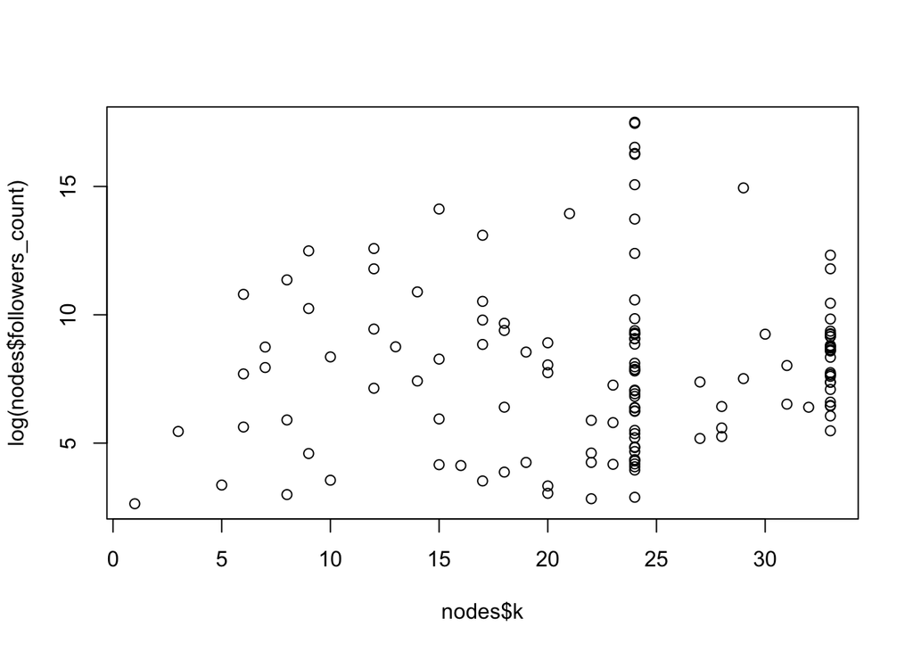

```r
# looking at what predicts being in the core
nodes$k <- coreness(g)
# number of followers?
plot(nodes$k, log(nodes$followers_count))
```

```r
cor(nodes$k, log(nodes$followers_count))
```

```
## [1] 0.09102953
```

```r
# text?
poir <- dfm(corpus(nodes[,c("description", "k")], text_field="description"))
head(textstat_keyness(poir, target=docvars(poir)$k==33,
                      measure="lr"), n=20)
```

```
##                  G2           p n_target n_reference
## school     7.782301 0.005276054        8           4
## &          7.521373 0.006097118       16          19
## usc        5.703835 0.016927889       14          18
## center     5.425831 0.019840994        6           3
## shaping    4.613143 0.031727836        3           0
## for        4.194837 0.040547244       15          23
## a          3.775917 0.051995401        8           8
## education  3.668911 0.055436377        5           3
## the        2.835163 0.092221448       36          79
## you        2.584930 0.107885152        3           1
## change     2.584930 0.107885152        3           1
## journalism 2.584930 0.107885152        3           1
## to         2.413369 0.120303230        9          14
## dornsife   2.251393 0.133494144        2           0
## academic   2.251393 0.133494144        2           0
## humanities 2.251393 0.133494144        2           0
## sciences   2.251393 0.133494144        2           0
## with       2.251393 0.133494144        2           0
## fostering  2.251393 0.133494144        2           0
## instagram  2.251393 0.133494144        2           0
```

```r
head(textstat_keyness(poir, target=docvars(poir)$k<5,
                      measure="lr"), n=20)
```

```
##                          G2          p n_target n_reference
## science        3.7072849954 0.05417545        2          31
## political      3.2598286147 0.07099655        2          37
## assistant      1.7796165999 0.18219641        1           5
## professor      1.5037237810 0.22009929        1           7
## student        1.2105717370 0.27121892        1          10
## southern       0.9397763156 0.33233537        1          14
## phd            0.9397763156 0.33233537        1          14
## of             0.8531906330 0.35565129        2         110
## california     0.8354276367 0.36070775        1          16
## university     0.7049193744 0.40113563        1          19
## at             0.4324209091 0.51080343        1          28
## usc            0.3675731776 0.54433008        1          31
## ,              0.0237610379 0.87749449        1         146
## and           -0.0001319675 0.99083434        0          87
## british       -0.0117164030 0.91380346        0           1
## top-20        -0.0117164030 0.91380346        0           1
## gould         -0.0117164030 0.91380346        0           1
## world-class   -0.0117164030 0.91380346        0           1
## unparalleled  -0.0117164030 0.91380346        0           1
## opportunities -0.0117164030 0.91380346        0           1
```

If you want to learn more about this technique, we recently published a [paper in PLOS ONE](http://journals.plos.org/plosone/article?id=10.1371/journal.pone.0143611) where we use it to study large-scale Twitter networks in the context of protest events.

```r
library(netdemR)
options(stringsAsFactors=F)
oauth_folder = "~/Dropbox/credentials/twitter"

accounts <- getFriends("uscpoir", oauth_folder=oauth_folder)

# creating folders (if they do not exists)
try(dir.create("friends"))

# first check if there's any list of friends already downloaded to 'outfolder'
accounts.done <- gsub(".rdata", "", list.files("data"))
accounts.left <- accounts[accounts %in% accounts.done == FALSE]
accounts.left <- accounts.left[!is.na(accounts.left)]

# loop over the rest of accounts, downloading friend lists from API
while (length(accounts.left) > 0){

    # sample randomly one account to get friends
    new.user <- sample(accounts.left, 1)
    #new.user <- accounts.left[1]
    cat(new.user, "---", length(accounts.left), " accounts left!\n")

    # download followers (with some exception handling...)
    error <- tryCatch(friends <- getFriends(user_id=new.user,
        oauth_folder=oauth_folder, sleep=0.5, verbose=FALSE), error=function(e) e)
    if (inherits(error, 'error')) {
        cat("Error! On to the next one...")
        accounts.left <- accounts.left[-which(accounts.left %in% new.user)]
        next
    }

    # save to file and remove from lists of "accounts.left"
    file.name <- paste0("friends/", new.user, ".rdata")
    save(friends, file=file.name)
    accounts.left <- accounts.left[-which(accounts.left %in% new.user)]

}

# keeping only those for which we have the name
accounts <- gsub(".rdata", "", list.files("friends"))

# reading and creating network
edges <- list()
for (i in 1:length(accounts)){
    file.name <- paste0("friends/", accounts[i], ".rdata")
    load(file.name)
    if (length(friends)==0){ next }
    chosen <- accounts[accounts %in% friends]
    if (length(chosen)==0){ next }
    edges[[i]] <- data.frame(
        source = accounts[i], target = chosen)
}

edges <- do.call(rbind, edges)
nodes <- data.frame(id_str=unique(c(edges$source, edges$target)))

# adding user data
users <- getUsersBatch(ids=nodes$id_str, oauth_folder=oauth_folder)
nodes <- merge(nodes, users)

library(igraph)
g <- graph_from_data_frame(d=edges, vertices=nodes, directed=TRUE)
g

names(nodes)[1:2] <- c("Id", "Label")
names(edges)[1:2] <- c("Source", "Target")
write.csv(nodes, file="../data/poir-nodes.csv", row.names=FALSE)
write.csv(edges, file="../data/poir-edges.csv", row.names=FALSE)
```